# Lab 1- Checkpoint 2

Joab de Araújo

29 de março de 2018

```r
library(tidyverse)
library(here)
library(knitr)
library(ggplot2)
theme_set(theme_bw())
```

# **Descrevendo as variáveis utilizadas**

```r
projetos = read_csv(here::here("data/projetos.csv"))
```

```r
projetos = projetos %>%
    filter(lang != "javascript")
```

Nesse relatório serão apresentado os resultados obtidos, para responder os seguintes questionamentos:

1. Como são os tamanhos de time nos projetos que usam travis em Java e em Ruby nos nossos dados?
2. Ao comparar projetos em Java e em Ruby que tenham ao menos 10 contribuidores no time nos nossos dados, projetos de qual linguagem *variam mais* na proporção de builds cujo resultado é sucesso?

Para responder ambas as perguntas foram utilizados as variáveis:

- **lang** e **team**, para responder a primeira pergunta;
- **lang** e **build_success_prop**, para responder a segunda pergunta.

Antes de apresentar os resultados, a seguir será apresentado uma breve descrição de cada variável utilizada:

- **lang**: Linguagem predominante do projeto segundo o Github;
- **team**: Tamanho do time(número de desenvolvedores) de cada projeto;
- **build_success_prop**: A proporção de copilações que tiveram sucesso em relação ao número de copilações totais.

Essas variáveis foram obtidas do site [TravisTorrent](https://travistorrent.testroots.org/) e toda a análise dos dados foi feito usando a linguagem R.

# Descrevendo a distribuição da variável *team*

Com o gráfico [BoxPlot](https://pt.wikipedia.org/wiki/Diagrama_de_caixa), é possível observar valores de centralidade como a mediana, e também valores de extremidades e [*outliers*](https://pt.wikipedia.org/wiki/Outlier).

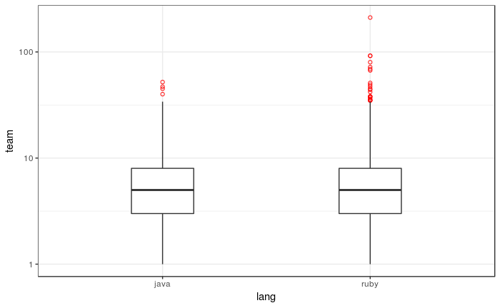

```r
  ggplot(projetos, aes(x = lang, y = team)) +
  geom_boxplot(width = .3, outlier.colour = "red",  outlier.shape = 1) +
    scale_y_log10()
```

Os valores na tabela gerada pela sumarização, ratificam o que foi visualizado no BoxPlot

```r
Mode <- function(x) {
  t <- table(x)
  return(as.numeric(names(t)[t == max(t)]))

}
```

```r
projetos %>%
  group_by(lang) %>%
 summarise(iqr = IQR(team),
 media = mean(team),
 moda = Mode(team),
 mediana = median(team),
 sd = sd(team))
```

| lang | iqr | media | moda | mediana | sd |
| --- | --- | --- | --- | --- | --- |
| java | 5 | 7.034704 | 2 | 5 | 7.048028 |
| ruby | 5 | 7.347333 | 2 | 5 | 11.348344 |

# Simetria

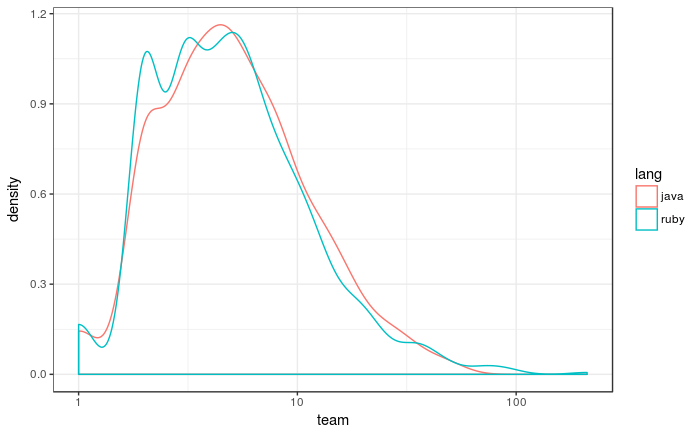

```r
projetos %>%
    ggplot(aes(x = team, color=lang)) +
    geom_density() + scale_x_log10()
```

# Concentração

Em termos de concentração, pode ser visto que os times do Ruby tem alguns valores mais dispersos, porém ambos tem uma concentração grande abaixo de 10 times.

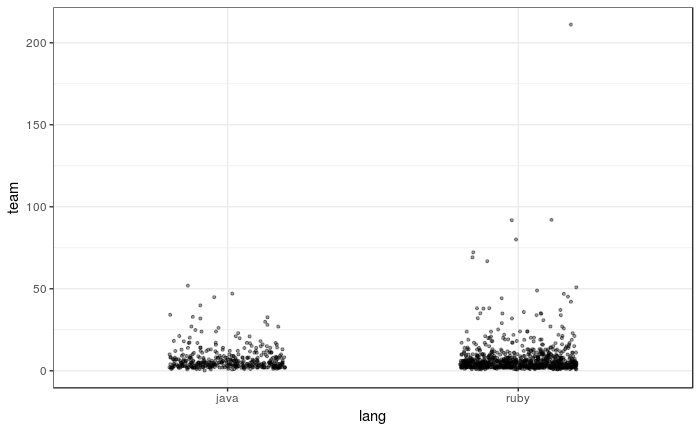

```r
projetos %>%
    ggplot(aes(x = lang, y = team)) +
    geom_jitter(alpha = .4, width = .2, size = .8)
```

# Finalizando a variável *team*

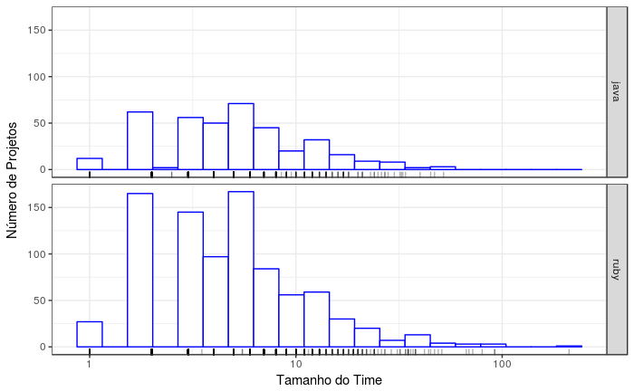

```r
projetos %>%
    ggplot(aes(x = team)) +
    geom_histogram(bins = 20, fill = "white", color = "blue") + labs(x="Tamanho do Time", y="Número de Projetos") + facet_grid(lang ~ .) + geom_rug(alpha = .3) +
   scale_x_log10()
```

# Analisando a variável *build_success_prop*

Filtragem para analisar apenas os times que tenham ao menos 10 membros

```r
projetos2 = projetos %>%
    filter(team >= 10)
```

# Variação de valores

Como pode ser observado pela dispersão dos valores, o java aparenta ter uma variação maior, do que Ruby, já que a maioria dos valores estão mais próximos uns dos outros.

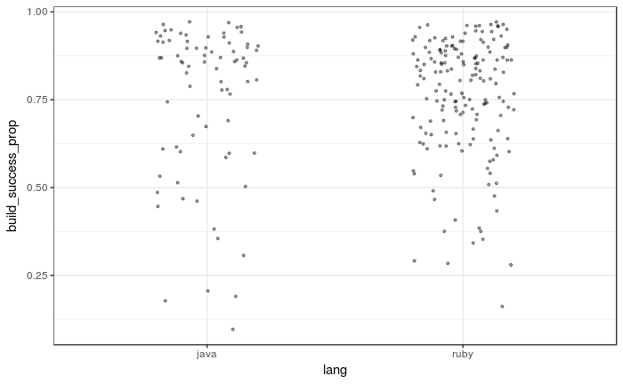

```r
projetos2 %>%
    ggplot(aes(x = lang, y = build_success_prop)) +
    geom_jitter(alpha = .4, width = .2, size = .8)
```

# Simetria

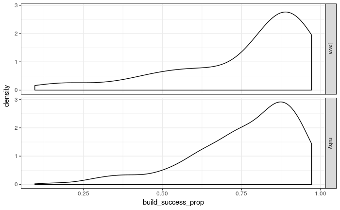

```r
projetos2 %>%
    ggplot(aes(x = build_success_prop)) +
    geom_density() + facet_grid(lang ~ .)
```

# Valores centrais, extremos e outliers

Como pode ser observado os variam mais de um para outra linguagem, há uma maior [IQR](http://www.statisticshowto.com/probability-and-statistics/interquartile-range/) em Java, pois há uma maior variação dos valores assim influenciando no valor de intervalo dos quartis, e isso pode ser visto nos resultados que encontra-se na tabela gerado da sumarização com a variância.

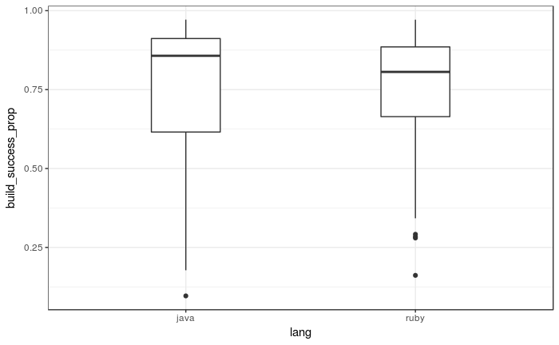

```r
ggplot(projetos2, aes(x = lang, y = build_success_prop)) +
  geom_boxplot(width = .3)
```

```r
projetos2 %>%
  group_by(lang) %>%
 summarise(iqr = IQR(build_success_prop),
 media = mean(build_success_prop),
 mediana = median(build_success_prop),
 variancia = var(build_success_prop),
 sd = sd(build_success_prop))
```

| lang | iqr | media | mediana | variancia | sd |
| --- | --- | --- | --- | --- | --- |
| java | 0.2962457 | 0.7570042 | 0.8570853 | 0.0474507 | 0.2178318 |
| ruby | 0.2208485 | 0.7593909 | 0.8060672 | 0.0279831 | 0.1672815 |